# NASS vs Remote Sensing Validation

Jill Deines

Friday, November 18, 2016

Goal: Compare irrigated acreages between remote sensing products and USDA NASS Ag Census Data. NASS data acquired through the Quick Stats API.

**R Packages Needed**

- `httr`: Vignette at https://cran.r-project.org/web/packages/httr/vignettes/quickstart.html

```r
# for API interaction
library(httr)
library(jsonlite)
library(maps)  # to translate state fp codes to 2 letter abbrevs

# for data manipulation
library(tidyr)
library(ggplot2)

# my functions (to be packaged)
source('functions/getNASS.R')
source('functions/cleanNassCensusCounty.R')
source('functions/stat_smooth_func.R')
```

## Load county data

In GEE, I calculated the number of cells of each classification type in each county fully contained within the RRB/RRCA boundary.

Here, I load this dataset from yearly files, add a year attribute, and split out the histogram column from the GEE ‘dictionary’ format to individual columns, converting cell counts to areas (both retained).

TO DO: The histogram splitting part could probably be more elegant, and certainly more robust to apply to any classification used.

```r
yearsDesired <- c(1997,2002, 2007, 2012)
cellArea <- 30*30 # m^2

countyDir <- 'C:/Users/deinesji/Google Drive/GEE_tableExports/county_counts_RRB_test2_cleaned'

# get filenames
countyfiles <- list.files(countyDir, pattern="*cleaned.csv")
# read in to a single dataframe
countyAll0 = do.call(rbind, lapply(countyfiles, function(x) {
              csv <- read.csv(paste0(countyDir,'/',x), stringsAsFactors = FALSE)
              csv$year <- as.numeric(substr(x, start=1,stop=4))
              csv$fips5 <- sprintf("%05d",csv$GEOID)
              csv$fips3 <- sprintf("%03d",csv$COUNTYFP)
              csv$state2 <- sprintf("%02d",csv$STATEFP)
              csv <- csv[,c('fips5','state2','fips3','histogram','name','year')]
            }))

# subset for the years desired
countyAll <- countyAll0[countyAll0$year %in% yearsDesired,]

# split up the histogram column (check order is 1,2,null,0)
for(i in 1:length(countyAll$histogram)){
  # split histogram dictionary by = and ,
  vars = unlist(strsplit(countyAll$histogram[i], split="[=]|[,]|[}]"))
  # extract relevant bits
  countyAll$irrCount[i] <- as.numeric(vars[2])
  countyAll$dryCount[i] <- as.numeric(vars[8])
  countyAll$nonCount[i] <- as.numeric(vars[4])
  countyAll$nullCount[i] <- as.numeric(vars[6])
  # convert to Area m^2
  countyAll$irrArea.m2[i] <- countyAll$irrCount[i] * cellArea
  countyAll$dryArea.m2[i] <- countyAll$dryCount[i] * cellArea
  countyAll$nonArea.m2[i] <- countyAll$nonCount[i] * cellArea
  countyAll$nullArea.m2[i] <- countyAll$nullCount[i] * cellArea
  # add Area km^2
  countyAll$irrArea.km2[i] <- countyAll$irrArea.m2[i] * 10e-7
  countyAll$dryArea.km2[i] <- countyAll$dryArea.m2[i] * 10e-7
  countyAll$nonArea.km2[i] <- countyAll$nonArea.m2[i] * 10e-7
  countyAll$nullArea.km2[i] <- countyAll$nullArea.m2[i] * 10e-7
}

# add a state 2-letter abbrev column
# fill in state abbrevs column based on FIPS
data(state.fips)  # from maps package
state.fips$STATEFP <- sprintf("%02d",state.fips$fips) # add leading zero
countyAll <- merge(countyAll, state.fips[,c('abb','STATEFP')],
                   by.x = 'state2', by.y = 'STATEFP',all.y=F)

# # write out csv for Anthony to use
# anthony <- countyAll[countyAll$year == 2002,c('state2','fips5','fips3','abb')]
# outdir <- 'C:/Users/deinesji/Dropbox/1PhdJill/hpa/irrigation/data/nass'
# outfile3 <- 'NASS_countiesToGet_forADK.csv'
# write.csv(anthony, paste0(outdir, '/', outfile3), row.names=F)
```

## Get and Clean NASS Data

From the NASS Quick Stats API, using county list generated above

### Get Data

And write out to not rely on NASS API

- API website: http://quickstats.nass.usda.gov/api
- My API key: 28EAA9E6-8060-34A4-981A-B2ED4692228A

```r
# set up variables for data calls
apiKey <- '28EAA9E6-8060-34A4-981A-B2ED4692228A'
program = 'CENSUS'
sector <- 'CROPS'
group <- 'FIELD CROPS'
aggregation <- 'COUNTY'

# get just 1 set of counties (so for 1 year)
counties <- countyAll[countyAll$year == unique(countyAll$year)[1],]

# make empty list to populate, and loop through counties
nass.list <- list()
for(i in 1:nrow(counties)){
  nass.list[[i]] <- getNASS(apiKey, program, sector, group, aggregation,
                              state = counties$abb[i],
                              county = counties$fips3[i])
}

# convert list of data frames to 1 giant dataframe
nass.df <- do.call("rbind",nass.list)

# write out raw data
outdir <- 'C:/Users/deinesji/Dropbox/1PhdJill/hpa/irrigation/data/nass'
outfile <- 'NASS_FieldCrops_County_RRB_raw.csv'
write.csv(nass.df, paste0(outdir, '/', outfile), row.names=F)
```

### clean data

load raw nass download file, clean it up

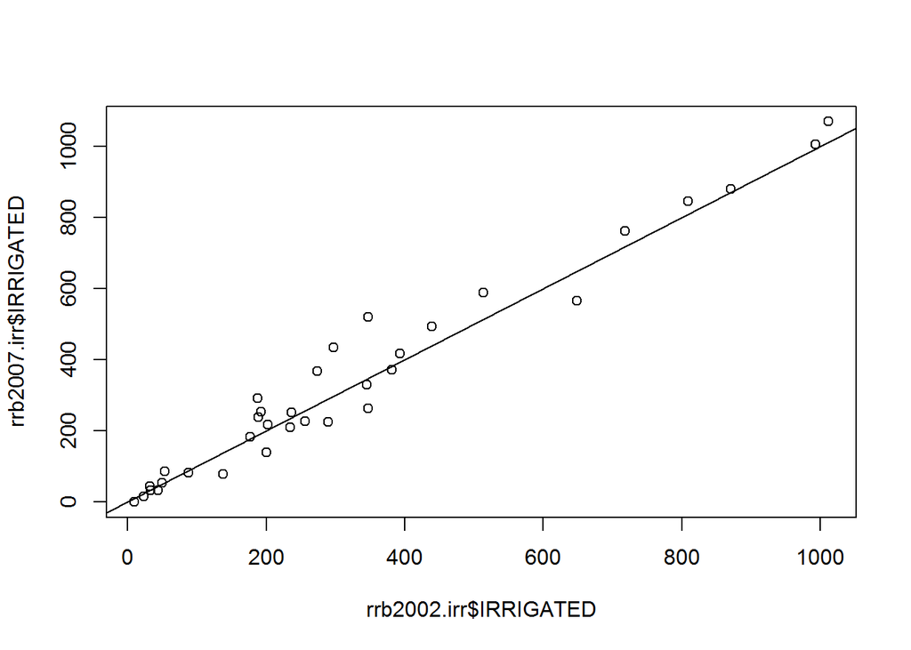

```r
# load data
outdir <- 'C:/Users/deinesji/Dropbox/1PhdJill/hpa/irrigation/data/nass'
outfile <- 'NASS_FieldCrops_County_RRB_raw.csv'
nass.df <- read.csv(paste0(outdir, '/', outfile), stringsAsFactors=F)

# # get a list of commodities for Anthony
#  # remove (D) values, remove commas (!), convert to numeric
#   nass.df <- nass.df[!grepl('(D)',nass.df$Value),]
#   nass.df$Value <- gsub(",", "", nass.df$Value, fixed = T)
#   nass.df$Value <- as.numeric(nass.df$Value)
#
#   # keep only records with "ACRES HARVESTED"
#   phrase <- 'ACRES HARVESTED'
#   nass.df <- nass.df[grepl(phrase,nass.df$short_desc),]
#
#   commodities <- unique(nass.df$commodity_desc)
#   outfile2 <- 'NASS_commodities_Anthony.csv'
#   write.csv(commodities, paste0(outdir, '/', outfile2), row.names=F)

# clean data
rrb1997 <- cleanNassCensusCounty(nass.df, year = 1997)
rrb2002 <- cleanNassCensusCounty(nass.df, year = 2002)
rrb2007 <- cleanNassCensusCounty(nass.df, year = 2007)
rrb2012 <- cleanNassCensusCounty(nass.df, year = 2012)

# get irrigated acreage by county
rrb1997.irr <- aggregate(IRRIGATED ~ fips5, data=rrb1997, FUN='sum')
rrb2002.irr <- aggregate(IRRIGATED ~ fips5, data=rrb2002, FUN='sum')
rrb2007.irr <- aggregate(IRRIGATED ~ fips5, data=rrb2007, FUN='sum')
rrb2012.irr <- aggregate(IRRIGATED ~ fips5, data=rrb2012, FUN='sum')

# add years
rrb1997.irr$year <- 1997
rrb2002.irr$year <- 2002
rrb2007.irr$year <- 2007
rrb2012.irr$year <- 2012

# for fun, see county change
plot(rrb2002.irr$IRRIGATED, rrb2007.irr$IRRIGATED)
abline(b=1, a=0)
```

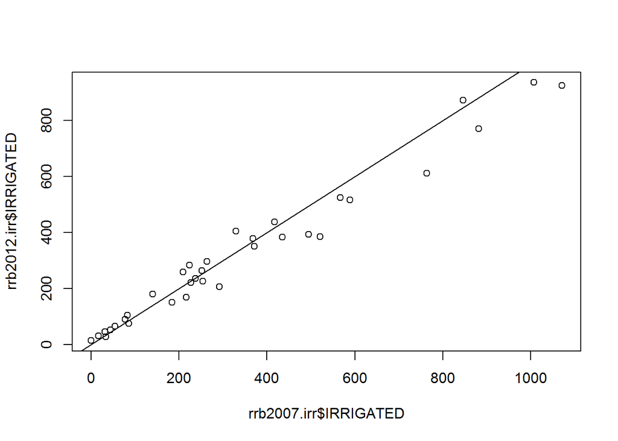

```r
plot(rrb2007.irr$IRRIGATED, rrb2012.irr$IRRIGATED)
abline(b=1, a=0)
```

## Compare!!

Here we go: compare irrigated areas by county

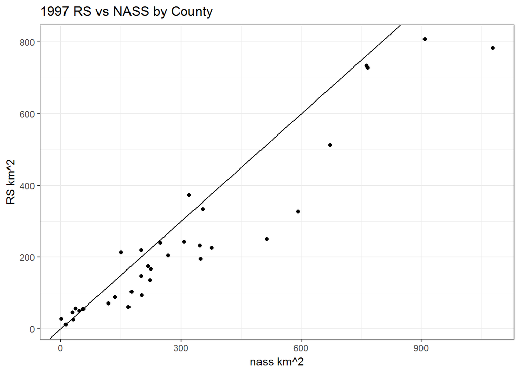

```r
# merge data
countyAll.1997 <- countyAll[countyAll$year == 1997,]
merged1997 <- merge(rrb1997.irr, countyAll.1997[,c('fips5','irrArea.km2')])

ggplot(merged1997, aes(x=IRRIGATED,y=irrArea.km2)) +
  geom_point() +
  geom_abline(slope = 1, intercept = 0) +
  ylab('RS km^2') + xlab('nass km^2') +
  ggtitle('1997 RS vs NASS by County') + theme_bw()
```

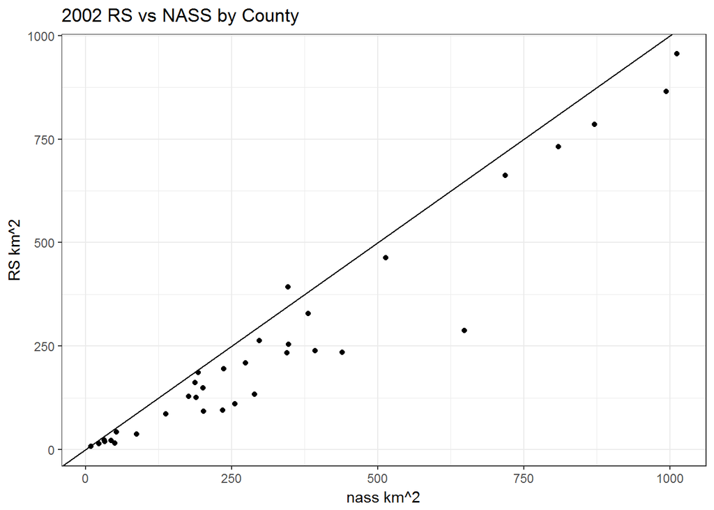

```r
# merge data
countyAll.2002 <- countyAll[countyAll$year == 2002,]
merged2002 <- merge(rrb2002.irr, countyAll.2002[,c('fips5','irrArea.km2')])

ggplot(merged2002, aes(x=IRRIGATED,y=irrArea.km2)) +
  geom_point() +
  geom_abline(slope = 1, intercept = 0) +
  ylab('RS km^2') + xlab('nass km^2') +
  ggtitle('2002 RS vs NASS by County') + theme_bw()
```

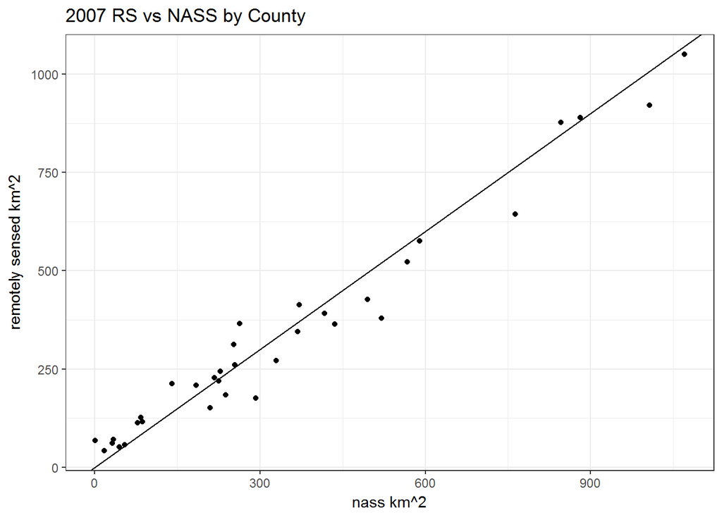

```r
# 2007 -----------------------------------------------------

countyAll.2007 <- countyAll[countyAll$year == 2007,]
merged2007 <- merge(rrb2007.irr, countyAll.2007[,c('fips5','irrArea.km2')])

ggplot(merged2007, aes(x=IRRIGATED,y=irrArea.km2)) +
  geom_point() +
  geom_abline(slope = 1, intercept = 0) +
  ylab('remotely sensed km^2') + xlab('nass km^2') +
  ggtitle('2007 RS vs NASS by County') + theme_bw()
```

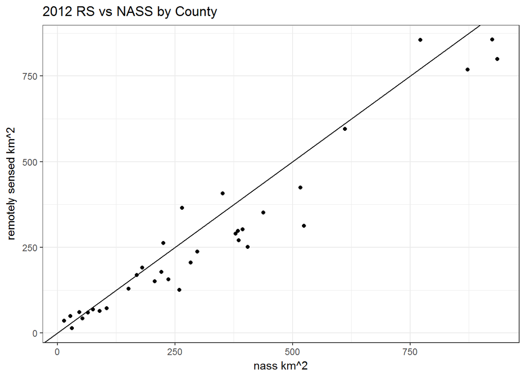

```r
# 2012 -----------------------------------------------------

countyAll.2012 <- countyAll[countyAll$year == 2012,]
merged2012 <- merge(rrb2012.irr, countyAll.2012[,c('fips5','irrArea.km2')])

ggplot(merged2012, aes(x=IRRIGATED,y=irrArea.km2)) +
  geom_point() +
  geom_abline(slope = 1, intercept = 0) +
  ylab('remotely sensed km^2') + xlab('nass km^2') +
  ggtitle('2012 RS vs NASS by County') + theme_bw()
```

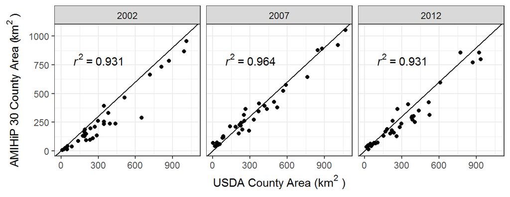

```r
allyears <- rbind(merged2002, merged2007, merged2012)

ggplot(allyears, aes(x=IRRIGATED,y=irrArea.km2)) +
  geom_point() +
  geom_abline(slope = 1, intercept = 0) +
  stat_smooth_func(geom="text",method="lm",hjust=0,parse=TRUE, xpos = 100, ypos = 800) +
  #geom_smooth(method="lm",se=FALSE) +
  facet_wrap(~year, nrow=1) +
  ylab(expression(paste("AMIHiP 30 County Area (", km^2," )"))) +
  xlab(expression(paste('USDA County Area (', km^2,' )'))) + theme_bw() #+
```

```r
  #ggtitle('2012 RS vs NASS by County')
```

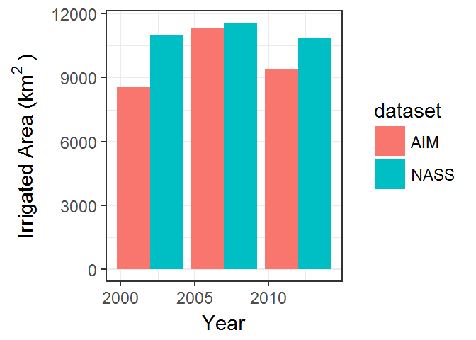

```r
areadata <- allyears
names(areadata) <- c('fips5', 'NASS','Year','AIM')

# sum area by year
areaAgg <- aggregate(cbind(NASS, AIM) ~ Year, data = areadata, FUN = 'sum')

# long format
area.gg <- gather(areaAgg, key = dataset, value = sq_km, NASS:AIM)

ggplot(data = area.gg, aes(Year, sq_km)) +
  geom_bar(aes(fill = dataset), position = 'dodge', stat='identity') +
   ylab(expression(paste("Irrigated Area (", km^2," )"))) +
  theme_bw()
```